# Risk Factor Analysis

## Outcome Variable

**Outcome Variable:** stunted

## Predictor Variables

**Intervention Variable:** earlybf

**Adjustment Set:**

unadjusted

## Stratifying Variables

The analysis was stratified on these variable(s):

- agecat
- studyid
- country

## Data Summary

| agecat | studyid | country | earlybf | stunted | n_cell | n |
| --- | --- | --- | --- | --- | --- | --- |
| Birth | EE | PAKISTAN | 1 | 0 | 28 | 229 |
| Birth | EE | PAKISTAN | 1 | 1 | 16 | 229 |
| Birth | EE | PAKISTAN | 0 | 0 | 105 | 229 |
| Birth | EE | PAKISTAN | 0 | 1 | 80 | 229 |
| Birth | GMS-Nepal | NEPAL | 1 | 0 | 152 | 632 |
| Birth | GMS-Nepal | NEPAL | 1 | 1 | 28 | 632 |
| Birth | GMS-Nepal | NEPAL | 0 | 0 | 373 | 632 |
| Birth | GMS-Nepal | NEPAL | 0 | 1 | 79 | 632 |
| Birth | JiVitA-3 | BANGLADESH | 1 | 0 | 85 | 22370 |
| Birth | JiVitA-3 | BANGLADESH | 1 | 1 | 151 | 22370 |
| Birth | JiVitA-3 | BANGLADESH | 0 | 0 | 14924 | 22370 |
| Birth | JiVitA-3 | BANGLADESH | 0 | 1 | 7210 | 22370 |
| Birth | JiVitA-4 | BANGLADESH | 1 | 0 | 1344 | 2823 |
| Birth | JiVitA-4 | BANGLADESH | 1 | 1 | 568 | 2823 |
| Birth | JiVitA-4 | BANGLADESH | 0 | 0 | 622 | 2823 |
| Birth | JiVitA-4 | BANGLADESH | 0 | 1 | 289 | 2823 |
| Birth | MAL-ED | BANGLADESH | 1 | 0 | 126 | 230 |
| Birth | MAL-ED | BANGLADESH | 1 | 1 | 21 | 230 |
| Birth | MAL-ED | BANGLADESH | 0 | 0 | 60 | 230 |
| Birth | MAL-ED | BANGLADESH | 0 | 1 | 23 | 230 |
| Birth | MAL-ED | BRAZIL | 1 | 0 | 26 | 65 |
| Birth | MAL-ED | BRAZIL | 1 | 1 | 2 | 65 |
| Birth | MAL-ED | BRAZIL | 0 | 0 | 30 | 65 |
| Birth | MAL-ED | BRAZIL | 0 | 1 | 7 | 65 |
| Birth | MAL-ED | INDIA | 1 | 0 | 25 | 46 |
| Birth | MAL-ED | INDIA | 1 | 1 | 7 | 46 |
| Birth | MAL-ED | INDIA | 0 | 0 | 11 | 46 |
| Birth | MAL-ED | INDIA | 0 | 1 | 3 | 46 |
| Birth | MAL-ED | NEPAL | 1 | 0 | 13 | 27 |
| Birth | MAL-ED | NEPAL | 1 | 1 | 1 | 27 |

[output cut: 134 more lines]

The following strata were considered:

- agecat: 24 months, studyid: EE, country: PAKISTAN
- agecat: 24 months, studyid: GMS-Nepal, country: NEPAL
- agecat: 24 months, studyid: JiVitA-3, country: BANGLADESH
- agecat: 24 months, studyid: JiVitA-4, country: BANGLADESH
- agecat: 24 months, studyid: MAL-ED, country: BANGLADESH
- agecat: 24 months, studyid: MAL-ED, country: BRAZIL
- agecat: 24 months, studyid: MAL-ED, country: INDIA
- agecat: 24 months, studyid: MAL-ED, country: NEPAL
- agecat: 24 months, studyid: MAL-ED, country: PERU
- agecat: 24 months, studyid: MAL-ED, country: SOUTH AFRICA
- agecat: 24 months, studyid: MAL-ED, country: TANZANIA, UNITED REPUBLIC OF
- agecat: 24 months, studyid: NIH-Crypto, country: BANGLADESH
- agecat: 24 months, studyid: ZVITAMBO, country: ZIMBABWE
- agecat: 6 months, studyid: EE, country: PAKISTAN
- agecat: 6 months, studyid: GMS-Nepal, country: NEPAL
- agecat: 6 months, studyid: JiVitA-3, country: BANGLADESH
- agecat: 6 months, studyid: JiVitA-4, country: BANGLADESH
- agecat: 6 months, studyid: MAL-ED, country: BANGLADESH
- agecat: 6 months, studyid: MAL-ED, country: BRAZIL
- agecat: 6 months, studyid: MAL-ED, country: INDIA
- agecat: 6 months, studyid: MAL-ED, country: NEPAL
- agecat: 6 months, studyid: MAL-ED, country: PERU
- agecat: 6 months, studyid: MAL-ED, country: SOUTH AFRICA
- agecat: 6 months, studyid: MAL-ED, country: TANZANIA, UNITED REPUBLIC OF
- agecat: 6 months, studyid: NIH-Crypto, country: BANGLADESH
- agecat: 6 months, studyid: SAS-CompFeed, country: INDIA
- agecat: 6 months, studyid: ZVITAMBO, country: ZIMBABWE
- agecat: Birth, studyid: EE, country: PAKISTAN
- agecat: Birth, studyid: GMS-Nepal, country: NEPAL
- agecat: Birth, studyid: JiVitA-3, country: BANGLADESH
- agecat: Birth, studyid: JiVitA-4, country: BANGLADESH
- agecat: Birth, studyid: MAL-ED, country: BANGLADESH
- agecat: Birth, studyid: MAL-ED, country: BRAZIL
- agecat: Birth, studyid: MAL-ED, country: INDIA
- agecat: Birth, studyid: MAL-ED, country: NEPAL
- agecat: Birth, studyid: MAL-ED, country: PERU
- agecat: Birth, studyid: MAL-ED, country: SOUTH AFRICA
- agecat: Birth, studyid: MAL-ED, country: TANZANIA, UNITED REPUBLIC OF
- agecat: Birth, studyid: NIH-Crypto, country: BANGLADESH
- agecat: Birth, studyid: SAS-CompFeed, country: INDIA
- agecat: Birth, studyid: ZVITAMBO, country: ZIMBABWE

### Dropped Strata

Some strata were dropped due to rare outcomes:

- agecat: Birth, studyid: MAL-ED, country: BRAZIL
- agecat: Birth, studyid: MAL-ED, country: INDIA
- agecat: Birth, studyid: MAL-ED, country: NEPAL
- agecat: Birth, studyid: MAL-ED, country: SOUTH AFRICA
- agecat: Birth, studyid: MAL-ED, country: TANZANIA, UNITED REPUBLIC OF
- agecat: 6 months, studyid: MAL-ED, country: BRAZIL
- agecat: 6 months, studyid: MAL-ED, country: NEPAL
- agecat: 24 months, studyid: JiVitA-3, country: BANGLADESH
- agecat: 24 months, studyid: MAL-ED, country: BRAZIL

## Methods Detail

We’re interested in the causal parameters $E[Y_a]$ for all values of $a \in \mathcal{A}$. These parameters represent the mean outcome if, possibly contrary to fact, we intervened to set all units to have $A=a$. Under the randomization and positivity assumptions, these are identified by the statistical parameters $\psi_a=E_W[E_{Y|A,W}(Y|A=a,W)]$. In addition, we’re interested in the mean of $Y$, $E[Y]$ under no intervention (the observed mean). We will estimate these parameters by using SuperLearner to fit the relevant likelihood factors – $E_{Y|A,W}(Y|A=a,W)$ and $p(A=a|W)$, and then updating our likelihood fit using a joint TMLE.

For unadjusted analyses ($W=\{\}$), initial likelihoods were estimated using Lrnr_glm to estimate the simple $E(Y|A)$ and Lrnr_mean to estimate $p(A)$. For adjusted analyses, a small library containing Lrnr_glmnet, Lrnr_xgboost, and Lrnr_mean was used.

Having estimated these parameters, we will then use the delta method to estimate relative risks and attributable risks relative to a prespecified baseline level of $A$.

# Results Detail

## Results Plots

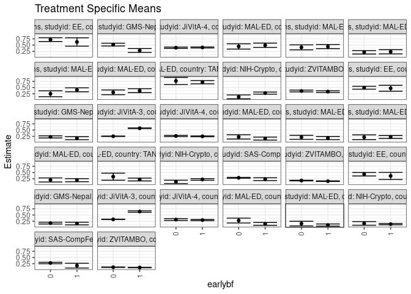

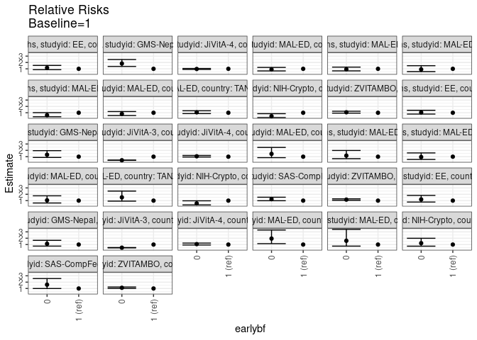

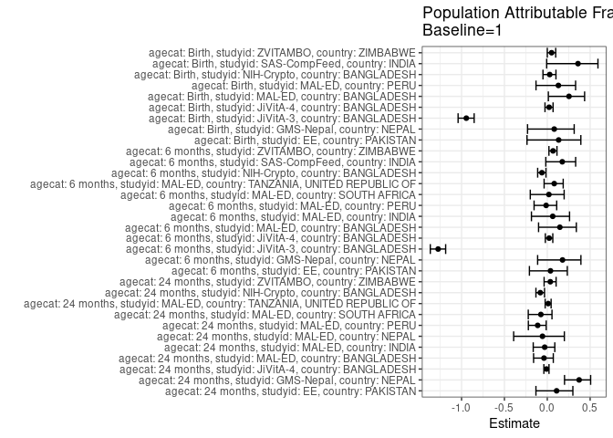

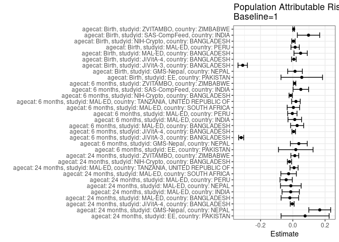

## Results Table

### Parameter: TSM

| agecat | studyid | country | intervention_level | baseline_level | estimate | ci_lower | ci_upper |
| --- | --- | --- | --- | --- | --- | --- | --- |
| Birth | EE | PAKISTAN | 1 | NA | 0.3636364 | 0.2211877 | 0.5060850 |
| Birth | EE | PAKISTAN | 0 | NA | 0.4324324 | 0.3608872 | 0.5039776 |
| Birth | GMS-Nepal | NEPAL | 1 | NA | 0.1555556 | 0.1025668 | 0.2085443 |
| Birth | GMS-Nepal | NEPAL | 0 | NA | 0.1747788 | 0.1397397 | 0.2098178 |
| Birth | JiVitA-3 | BANGLADESH | 1 | NA | 0.6398305 | 0.6104797 | 0.6691814 |
| Birth | JiVitA-3 | BANGLADESH | 0 | NA | 0.3257432 | 0.3182758 | 0.3332106 |
| Birth | JiVitA-4 | BANGLADESH | 1 | NA | 0.2970711 | 0.2728964 | 0.3212459 |
| Birth | JiVitA-4 | BANGLADESH | 0 | NA | 0.3172338 | 0.2807140 | 0.3537536 |
| Birth | MAL-ED | BANGLADESH | 1 | NA | 0.1428571 | 0.0861663 | 0.1995480 |
| Birth | MAL-ED | BANGLADESH | 0 | NA | 0.2771084 | 0.1806108 | 0.3736061 |
| Birth | MAL-ED | PERU | 1 | NA | 0.0971429 | 0.0531707 | 0.1411150 |
| Birth | MAL-ED | PERU | 0 | NA | 0.1551724 | 0.0617912 | 0.2485536 |
| Birth | NIH-Crypto | BANGLADESH | 1 | NA | 0.1340694 | 0.1075290 | 0.1606098 |
| Birth | NIH-Crypto | BANGLADESH | 0 | NA | 0.1632653 | 0.0900381 | 0.2364926 |
| Birth | SAS-CompFeed | INDIA | 1 | NA | 0.1744186 | 0.0774516 | 0.2713856 |
| Birth | SAS-CompFeed | INDIA | 0 | NA | 0.2792150 | 0.2505222 | 0.3079077 |
| Birth | ZVITAMBO | ZIMBABWE | 1 | NA | 0.0976205 | 0.0904358 | 0.1048052 |
| Birth | ZVITAMBO | ZIMBABWE | 0 | NA | 0.1086582 | 0.1006473 | 0.1166690 |
| 6 months | EE | PAKISTAN | 1 | NA | 0.4705882 | 0.3517895 | 0.5893869 |
| 6 months | EE | PAKISTAN | 0 | NA | 0.4931973 | 0.4359698 | 0.5504248 |
| 6 months | GMS-Nepal | NEPAL | 1 | NA | 0.1721854 | 0.1119087 | 0.2324622 |
| 6 months | GMS-Nepal | NEPAL | 0 | NA | 0.2250000 | 0.1818218 | 0.2681782 |
| 6 months | JiVitA-3 | BANGLADESH | 1 | NA | 0.5714286 | 0.5579680 | 0.5848891 |
| 6 months | JiVitA-3 | BANGLADESH | 0 | NA | 0.2507153 | 0.2423967 | 0.2590339 |
| 6 months | JiVitA-4 | BANGLADESH | 1 | NA | 0.2472527 | 0.2296446 | 0.2648609 |
| 6 months | JiVitA-4 | BANGLADESH | 0 | NA | 0.2625216 | 0.2381027 | 0.2869405 |
| 6 months | MAL-ED | BANGLADESH | 1 | NA | 0.1564626 | 0.0976116 | 0.2153135 |
| 6 months | MAL-ED | BANGLADESH | 0 | NA | 0.2258065 | 0.1406522 | 0.3109607 |
| 6 months | MAL-ED | INDIA | 1 | NA | 0.1785714 | 0.1149949 | 0.2421480 |
| 6 months | MAL-ED | INDIA | 0 | NA | 0.2083333 | 0.1269220 | 0.2897447 |
| 6 months | MAL-ED | PERU | 1 | NA | 0.2227723 | 0.1652847 | 0.2802599 |
| 6 months | MAL-ED | PERU | 0 | NA | 0.2112676 | 0.1161421 | 0.3063931 |
| 6 months | MAL-ED | SOUTH AFRICA | 1 | NA | 0.1923077 | 0.1303383 | 0.2542771 |
| 6 months | MAL-ED | SOUTH AFRICA | 0 | NA | 0.2021277 | 0.1207821 | 0.2834733 |
| 6 months | MAL-ED | TANZANIA, UNITED REPUBLIC OF | 1 | NA | 0.2195122 | 0.1627362 | 0.2762882 |
| 6 months | MAL-ED | TANZANIA, UNITED REPUBLIC OF | 0 | NA | 0.3333333 | 0.1904775 | 0.4761892 |
| 6 months | NIH-Crypto | BANGLADESH | 1 | NA | 0.2229402 | 0.1901286 | 0.2557519 |
| 6 months | NIH-Crypto | BANGLADESH | 0 | NA | 0.1250000 | 0.0587973 | 0.1912027 |
| 6 months | SAS-CompFeed | INDIA | 1 | NA | 0.2346939 | 0.1781778 | 0.2912099 |
| 6 months | SAS-CompFeed | INDIA | 0 | NA | 0.2883683 | 0.2709758 | 0.3057609 |
| 6 months | ZVITAMBO | ZIMBABWE | 1 | NA | 0.1531597 | 0.1421965 | 0.1641228 |
| 6 months | ZVITAMBO | ZIMBABWE | 0 | NA | 0.1770833 | 0.1645286 | 0.1896380 |
| 24 months | EE | PAKISTAN | 1 | NA | 0.6250000 | 0.4567493 | 0.7932507 |
| 24 months | EE | PAKISTAN | 0 | NA | 0.7196970 | 0.6428409 | 0.7965530 |
| 24 months | GMS-Nepal | NEPAL | 1 | NA | 0.2824427 | 0.2052646 | 0.3596209 |
| 24 months | GMS-Nepal | NEPAL | 0 | NA | 0.5191083 | 0.4637829 | 0.5744337 |
| 24 months | JiVitA-4 | BANGLADESH | 1 | NA | 0.4046680 | 0.3835989 | 0.4257370 |
| 24 months | JiVitA-4 | BANGLADESH | 0 | NA | 0.3941520 | 0.3672140 | 0.4210901 |
| 24 months | MAL-ED | BANGLADESH | 1 | NA | 0.4921875 | 0.4053731 | 0.5790019 |
| 24 months | MAL-ED | BANGLADESH | 0 | NA | 0.4457831 | 0.3385961 | 0.5529702 |
| 24 months | MAL-ED | INDIA | 1 | NA | 0.4402985 | 0.3560609 | 0.5245362 |
| 24 months | MAL-ED | INDIA | 0 | NA | 0.4086022 | 0.3084742 | 0.5087301 |
| 24 months | MAL-ED | NEPAL | 1 | NA | 0.2315789 | 0.1465650 | 0.3165928 |
| 24 months | MAL-ED | NEPAL | 0 | NA | 0.2105263 | 0.1410881 | 0.2799646 |
| 24 months | MAL-ED | PERU | 1 | NA | 0.4093960 | 0.3302447 | 0.4885473 |
| 24 months | MAL-ED | PERU | 0 | NA | 0.2500000 | 0.1320141 | 0.3679859 |
| 24 months | MAL-ED | SOUTH AFRICA | 1 | NA | 0.3750000 | 0.2957593 | 0.4542407 |
| 24 months | MAL-ED | SOUTH AFRICA | 0 | NA | 0.3076923 | 0.2126622 | 0.4027224 |
| 24 months | MAL-ED | TANZANIA, UNITED REPUBLIC OF | 1 | NA | 0.7166667 | 0.6506830 | 0.7826503 |
| 24 months | MAL-ED | TANZANIA, UNITED REPUBLIC OF | 0 | NA | 0.7647059 | 0.6217907 | 0.9076211 |
| 24 months | NIH-Crypto | BANGLADESH | 1 | NA | 0.2776524 | 0.2359085 | 0.3193963 |
| 24 months | NIH-Crypto | BANGLADESH | 0 | NA | 0.1267606 | 0.0492965 | 0.2042247 |
| 24 months | ZVITAMBO | ZIMBABWE | 1 | NA | 0.3375174 | 0.3028933 | 0.3721415 |
| 24 months | ZVITAMBO | ZIMBABWE | 0 | NA | 0.3628447 | 0.3269297 | 0.3987597 |

### Parameter: E(Y)

| agecat | studyid | country | intervention_level | baseline_level | estimate | ci_lower | ci_upper |
| --- | --- | --- | --- | --- | --- | --- | --- |
| Birth | EE | PAKISTAN | NA | NA | 0.4192140 | 0.3551658 | 0.4832621 |
| Birth | GMS-Nepal | NEPAL | NA | NA | 0.1693038 | 0.1400429 | 0.1985647 |
| Birth | JiVitA-3 | BANGLADESH | NA | NA | 0.3290568 | 0.3216837 | 0.3364298 |
| Birth | JiVitA-4 | BANGLADESH | NA | NA | 0.3035778 | 0.2836422 | 0.3235133 |
| Birth | MAL-ED | BANGLADESH | NA | NA | 0.1913043 | 0.1403613 | 0.2422474 |
| Birth | MAL-ED | PERU | NA | NA | 0.1115880 | 0.0710726 | 0.1521034 |
| Birth | NIH-Crypto | BANGLADESH | NA | NA | 0.1379781 | 0.1129774 | 0.1629789 |
| Birth | SAS-CompFeed | INDIA | NA | NA | 0.2717481 | 0.2380003 | 0.3054960 |
| Birth | ZVITAMBO | ZIMBABWE | NA | NA | 0.1028007 | 0.0974452 | 0.1081563 |
| 6 months | EE | PAKISTAN | NA | NA | 0.4889503 | 0.4373849 | 0.5405157 |
| 6 months | GMS-Nepal | NEPAL | NA | NA | 0.2093933 | 0.1740812 | 0.2447055 |
| 6 months | JiVitA-3 | BANGLADESH | NA | NA | 0.2513830 | 0.2432594 | 0.2595066 |
| 6 months | JiVitA-4 | BANGLADESH | NA | NA | 0.2527427 | 0.2386864 | 0.2667990 |
| 6 months | MAL-ED | BANGLADESH | NA | NA | 0.1833333 | 0.1342773 | 0.2323893 |
| 6 months | MAL-ED | INDIA | NA | NA | 0.1906780 | 0.1404524 | 0.2409036 |
| 6 months | MAL-ED | PERU | NA | NA | 0.2197802 | 0.1705687 | 0.2689917 |
| 6 months | MAL-ED | SOUTH AFRICA | NA | NA | 0.1960000 | 0.1466935 | 0.2453065 |
| 6 months | MAL-ED | TANZANIA, UNITED REPUBLIC OF | NA | NA | 0.2388664 | 0.1855834 | 0.2921494 |
| 6 months | NIH-Crypto | BANGLADESH | NA | NA | 0.2097902 | 0.1799252 | 0.2396552 |
| 6 months | SAS-CompFeed | INDIA | NA | NA | 0.2844311 | 0.2666491 | 0.3022132 |
| 6 months | ZVITAMBO | ZIMBABWE | NA | NA | 0.1641985 | 0.1559224 | 0.1724746 |
| 24 months | EE | PAKISTAN | NA | NA | 0.7012195 | 0.6309515 | 0.7714875 |
| 24 months | GMS-Nepal | NEPAL | NA | NA | 0.4494382 | 0.4031687 | 0.4957077 |
| 24 months | JiVitA-4 | BANGLADESH | NA | NA | 0.4008838 | 0.3839145 | 0.4178532 |
| 24 months | MAL-ED | BANGLADESH | NA | NA | 0.4739336 | 0.4064004 | 0.5414669 |
| 24 months | MAL-ED | INDIA | NA | NA | 0.4273128 | 0.3628178 | 0.4918077 |
| 24 months | MAL-ED | NEPAL | NA | NA | 0.2192982 | 0.1654718 | 0.2731246 |
| 24 months | MAL-ED | PERU | NA | NA | 0.3681592 | 0.3013164 | 0.4350020 |
| 24 months | MAL-ED | SOUTH AFRICA | NA | NA | 0.3489362 | 0.2878666 | 0.4100058 |
| 24 months | MAL-ED | TANZANIA, UNITED REPUBLIC OF | NA | NA | 0.7242991 | 0.6642873 | 0.7843108 |
| 24 months | NIH-Crypto | BANGLADESH | NA | NA | 0.2568093 | 0.2190047 | 0.2946140 |
| 24 months | ZVITAMBO | ZIMBABWE | NA | NA | 0.3499289 | 0.3249898 | 0.3748679 |

### Parameter: RR

| agecat | studyid | country | intervention_level | baseline_level | estimate | ci_lower | ci_upper |
| --- | --- | --- | --- | --- | --- | --- | --- |
| Birth | EE | PAKISTAN | 1 | 1 | 1.0000000 | 1.0000000 | 1.0000000 |
| Birth | EE | PAKISTAN | 0 | 1 | 1.1891892 | 0.7772699 | 1.8194079 |
| Birth | GMS-Nepal | NEPAL | 1 | 1 | 1.0000000 | 1.0000000 | 1.0000000 |
| Birth | GMS-Nepal | NEPAL | 0 | 1 | 1.1235777 | 0.7567375 | 1.6682495 |
| Birth | JiVitA-3 | BANGLADESH | 1 | 1 | 1.0000000 | 1.0000000 | 1.0000000 |
| Birth | JiVitA-3 | BANGLADESH | 0 | 1 | 0.5091086 | 0.4840905 | 0.5354196 |
| Birth | JiVitA-4 | BANGLADESH | 1 | 1 | 1.0000000 | 1.0000000 | 1.0000000 |
| Birth | JiVitA-4 | BANGLADESH | 0 | 1 | 1.0678716 | 0.9258854 | 1.2316315 |
| Birth | MAL-ED | BANGLADESH | 1 | 1 | 1.0000000 | 1.0000000 | 1.0000000 |
| Birth | MAL-ED | BANGLADESH | 0 | 1 | 1.9397590 | 1.1440815 | 3.2888086 |
| Birth | MAL-ED | PERU | 1 | 1 | 1.0000000 | 1.0000000 | 1.0000000 |
| Birth | MAL-ED | PERU | 0 | 1 | 1.5973631 | 0.7522615 | 3.3918642 |
| Birth | NIH-Crypto | BANGLADESH | 1 | 1 | 1.0000000 | 1.0000000 | 1.0000000 |
| Birth | NIH-Crypto | BANGLADESH | 0 | 1 | 1.2177671 | 0.7458418 | 1.9882992 |
| Birth | SAS-CompFeed | INDIA | 1 | 1 | 1.0000000 | 1.0000000 | 1.0000000 |
| Birth | SAS-CompFeed | INDIA | 0 | 1 | 1.6008326 | 0.9977650 | 2.5684054 |
| Birth | ZVITAMBO | ZIMBABWE | 1 | 1 | 1.0000000 | 1.0000000 | 1.0000000 |
| Birth | ZVITAMBO | ZIMBABWE | 0 | 1 | 1.1130670 | 1.0029496 | 1.2352745 |
| 6 months | EE | PAKISTAN | 1 | 1 | 1.0000000 | 1.0000000 | 1.0000000 |
| 6 months | EE | PAKISTAN | 0 | 1 | 1.0480442 | 0.7938099 | 1.3837024 |
| 6 months | GMS-Nepal | NEPAL | 1 | 1 | 1.0000000 | 1.0000000 | 1.0000000 |
| 6 months | GMS-Nepal | NEPAL | 0 | 1 | 1.3067308 | 0.8766132 | 1.9478891 |
| 6 months | JiVitA-3 | BANGLADESH | 1 | 1 | 1.0000000 | 1.0000000 | 1.0000000 |
| 6 months | JiVitA-3 | BANGLADESH | 0 | 1 | 0.4387518 | 0.4211672 | 0.4570705 |
| 6 months | JiVitA-4 | BANGLADESH | 1 | 1 | 1.0000000 | 1.0000000 | 1.0000000 |
| 6 months | JiVitA-4 | BANGLADESH | 0 | 1 | 1.0617540 | 0.9426253 | 1.1959381 |
| 6 months | MAL-ED | BANGLADESH | 1 | 1 | 1.0000000 | 1.0000000 | 1.0000000 |
| 6 months | MAL-ED | BANGLADESH | 0 | 1 | 1.4431978 | 0.8472458 | 2.4583419 |
| 6 months | MAL-ED | INDIA | 1 | 1 | 1.0000000 | 1.0000000 | 1.0000000 |
| 6 months | MAL-ED | INDIA | 0 | 1 | 1.1666667 | 0.6876397 | 1.9793958 |
| 6 months | MAL-ED | PERU | 1 | 1 | 1.0000000 | 1.0000000 | 1.0000000 |
| 6 months | MAL-ED | PERU | 0 | 1 | 0.9483568 | 0.5644000 | 1.5935164 |
| 6 months | MAL-ED | SOUTH AFRICA | 1 | 1 | 1.0000000 | 1.0000000 | 1.0000000 |
| 6 months | MAL-ED | SOUTH AFRICA | 0 | 1 | 1.0510638 | 0.6276594 | 1.7600870 |
| 6 months | MAL-ED | TANZANIA, UNITED REPUBLIC OF | 1 | 1 | 1.0000000 | 1.0000000 | 1.0000000 |
| 6 months | MAL-ED | TANZANIA, UNITED REPUBLIC OF | 0 | 1 | 1.5185185 | 0.9205054 | 2.5050354 |
| 6 months | NIH-Crypto | BANGLADESH | 1 | 1 | 1.0000000 | 1.0000000 | 1.0000000 |
| 6 months | NIH-Crypto | BANGLADESH | 0 | 1 | 0.5606884 | 0.3235892 | 0.9715142 |
| 6 months | SAS-CompFeed | INDIA | 1 | 1 | 1.0000000 | 1.0000000 | 1.0000000 |
| 6 months | SAS-CompFeed | INDIA | 0 | 1 | 1.2286999 | 0.9822774 | 1.5369419 |
| 6 months | ZVITAMBO | ZIMBABWE | 1 | 1 | 1.0000000 | 1.0000000 | 1.0000000 |
| 6 months | ZVITAMBO | ZIMBABWE | 0 | 1 | 1.1562008 | 1.0453920 | 1.2787551 |
| 24 months | EE | PAKISTAN | 1 | 1 | 1.0000000 | 1.0000000 | 1.0000000 |
| 24 months | EE | PAKISTAN | 0 | 1 | 1.1515152 | 0.8619740 | 1.5383145 |
| 24 months | GMS-Nepal | NEPAL | 1 | 1 | 1.0000000 | 1.0000000 | 1.0000000 |
| 24 months | GMS-Nepal | NEPAL | 0 | 1 | 1.8379239 | 1.3707188 | 2.4643745 |
| 24 months | JiVitA-4 | BANGLADESH | 1 | 1 | 1.0000000 | 1.0000000 | 1.0000000 |
| 24 months | JiVitA-4 | BANGLADESH | 0 | 1 | 0.9740134 | 0.8955600 | 1.0593396 |
| 24 months | MAL-ED | BANGLADESH | 1 | 1 | 1.0000000 | 1.0000000 | 1.0000000 |
| 24 months | MAL-ED | BANGLADESH | 0 | 1 | 0.9057181 | 0.6721780 | 1.2203989 |
| 24 months | MAL-ED | INDIA | 1 | 1 | 1.0000000 | 1.0000000 | 1.0000000 |
| 24 months | MAL-ED | INDIA | 0 | 1 | 0.9280117 | 0.6800417 | 1.2664012 |
| 24 months | MAL-ED | NEPAL | 1 | 1 | 1.0000000 | 1.0000000 | 1.0000000 |
| 24 months | MAL-ED | NEPAL | 0 | 1 | 0.9090909 | 0.5549798 | 1.4891465 |
| 24 months | MAL-ED | PERU | 1 | 1 | 1.0000000 | 1.0000000 | 1.0000000 |
| 24 months | MAL-ED | PERU | 0 | 1 | 0.6106557 | 0.3666925 | 1.0169294 |
| 24 months | MAL-ED | SOUTH AFRICA | 1 | 1 | 1.0000000 | 1.0000000 | 1.0000000 |
| 24 months | MAL-ED | SOUTH AFRICA | 0 | 1 | 0.8205128 | 0.5643714 | 1.1929047 |
| 24 months | MAL-ED | TANZANIA, UNITED REPUBLIC OF | 1 | 1 | 1.0000000 | 1.0000000 | 1.0000000 |
| 24 months | MAL-ED | TANZANIA, UNITED REPUBLIC OF | 0 | 1 | 1.0670315 | 0.8663581 | 1.3141865 |
| 24 months | NIH-Crypto | BANGLADESH | 1 | 1 | 1.0000000 | 1.0000000 | 1.0000000 |
| 24 months | NIH-Crypto | BANGLADESH | 0 | 1 | 0.4565441 | 0.2433150 | 0.8566365 |
| 24 months | ZVITAMBO | ZIMBABWE | 1 | 1 | 1.0000000 | 1.0000000 | 1.0000000 |
| 24 months | ZVITAMBO | ZIMBABWE | 0 | 1 | 1.0750399 | 0.9322130 | 1.2397497 |

### Parameter: PAR

| agecat | studyid | country | intervention_level | baseline_level | estimate | ci_lower | ci_upper |
| --- | --- | --- | --- | --- | --- | --- | --- |
| Birth | EE | PAKISTAN | 1 | NA | 0.0555776 | -0.0732484 | 0.1844036 |
| Birth | GMS-Nepal | NEPAL | 1 | NA | 0.0137482 | -0.0316899 | 0.0591864 |
| Birth | JiVitA-3 | BANGLADESH | 1 | NA | -0.3107737 | -0.3400102 | -0.2815372 |
| Birth | JiVitA-4 | BANGLADESH | 1 | NA | 0.0065066 | -0.0077933 | 0.0208065 |
| Birth | MAL-ED | BANGLADESH | 1 | NA | 0.0484472 | 0.0072051 | 0.0896893 |
| Birth | MAL-ED | PERU | 1 | NA | 0.0144451 | -0.0114503 | 0.0403405 |
| Birth | NIH-Crypto | BANGLADESH | 1 | NA | 0.0039087 | -0.0065438 | 0.0143613 |
| Birth | SAS-CompFeed | INDIA | 1 | NA | 0.0973295 | 0.0281469 | 0.1665122 |
| Birth | ZVITAMBO | ZIMBABWE | 1 | NA | 0.0051802 | 0.0001290 | 0.0102314 |
| 6 months | EE | PAKISTAN | 1 | NA | 0.0183620 | -0.0887358 | 0.1254599 |
| 6 months | GMS-Nepal | NEPAL | 1 | NA | 0.0372079 | -0.0150699 | 0.0894857 |
| 6 months | JiVitA-3 | BANGLADESH | 1 | NA | -0.3200455 | -0.3355472 | -0.3045439 |
| 6 months | JiVitA-4 | BANGLADESH | 1 | NA | 0.0054900 | -0.0055156 | 0.0164955 |
| 6 months | MAL-ED | BANGLADESH | 1 | NA | 0.0268707 | -0.0134681 | 0.0672096 |
| 6 months | MAL-ED | INDIA | 1 | NA | 0.0121065 | -0.0299532 | 0.0541663 |
| 6 months | MAL-ED | PERU | 1 | NA | -0.0029921 | -0.0319047 | 0.0259206 |
| 6 months | MAL-ED | SOUTH AFRICA | 1 | NA | 0.0036923 | -0.0347624 | 0.0421470 |
| 6 months | MAL-ED | TANZANIA, UNITED REPUBLIC OF | 1 | NA | 0.0193542 | -0.0073258 | 0.0460342 |
| 6 months | NIH-Crypto | BANGLADESH | 1 | NA | -0.0131500 | -0.0233685 | -0.0029316 |
| 6 months | SAS-CompFeed | INDIA | 1 | NA | 0.0497373 | 0.0017029 | 0.0977716 |
| 6 months | ZVITAMBO | ZIMBABWE | 1 | NA | 0.0110388 | 0.0033434 | 0.0187342 |
| 24 months | EE | PAKISTAN | 1 | NA | 0.0762195 | -0.0727729 | 0.2252119 |
| 24 months | GMS-Nepal | NEPAL | 1 | NA | 0.1669955 | 0.0992431 | 0.2347478 |
| 24 months | JiVitA-4 | BANGLADESH | 1 | NA | -0.0037841 | -0.0158171 | 0.0082488 |
| 24 months | MAL-ED | BANGLADESH | 1 | NA | -0.0182539 | -0.0725988 | 0.0360911 |
| 24 months | MAL-ED | INDIA | 1 | NA | -0.0129857 | -0.0666322 | 0.0406607 |
| 24 months | MAL-ED | NEPAL | 1 | NA | -0.0122807 | -0.0763263 | 0.0517649 |
| 24 months | MAL-ED | PERU | 1 | NA | -0.0412368 | -0.0792445 | -0.0032290 |
| 24 months | MAL-ED | SOUTH AFRICA | 1 | NA | -0.0260638 | -0.0741612 | 0.0220335 |
| 24 months | MAL-ED | TANZANIA, UNITED REPUBLIC OF | 1 | NA | 0.0076324 | -0.0174880 | 0.0327528 |
| 24 months | NIH-Crypto | BANGLADESH | 1 | NA | -0.0208430 | -0.0338062 | -0.0078799 |
| 24 months | ZVITAMBO | ZIMBABWE | 1 | NA | 0.0124114 | -0.0120443 | 0.0368672 |

### Parameter: PAF

| agecat | studyid | country | intervention_level | baseline_level | estimate | ci_lower | ci_upper |
| --- | --- | --- | --- | --- | --- | --- | --- |
| Birth | EE | PAKISTAN | 1 | NA | 0.1325758 | -0.2364426 | 0.3914600 |
| Birth | GMS-Nepal | NEPAL | 1 | NA | 0.0812046 | -0.2301803 | 0.3137713 |
| Birth | JiVitA-3 | BANGLADESH | 1 | NA | -0.9444380 | -1.0403095 | -0.8530715 |
| Birth | JiVitA-4 | BANGLADESH | 1 | NA | 0.0214331 | -0.0268004 | 0.0674009 |
| Birth | MAL-ED | BANGLADESH | 1 | NA | 0.2532468 | 0.0125306 | 0.4352833 |
| Birth | MAL-ED | PERU | 1 | NA | 0.1294505 | -0.1316004 | 0.3302792 |
| Birth | NIH-Crypto | BANGLADESH | 1 | NA | 0.0283287 | -0.0503283 | 0.1010953 |
| Birth | SAS-CompFeed | INDIA | 1 | NA | 0.3581608 | -0.0072437 | 0.5910051 |
| Birth | ZVITAMBO | ZIMBABWE | 1 | NA | 0.0503908 | 0.0000193 | 0.0982250 |
| 6 months | EE | PAKISTAN | 1 | NA | 0.0375540 | -0.2084480 | 0.2334778 |
| 6 months | GMS-Nepal | NEPAL | 1 | NA | 0.1776939 | -0.1126384 | 0.3922667 |
| 6 months | JiVitA-3 | BANGLADESH | 1 | NA | -1.2731391 | -1.3644565 | -1.1853484 |
| 6 months | JiVitA-4 | BANGLADESH | 1 | NA | 0.0217215 | -0.0227887 | 0.0642947 |
| 6 months | MAL-ED | BANGLADESH | 1 | NA | 0.1465677 | -0.1016289 | 0.3388457 |
| 6 months | MAL-ED | INDIA | 1 | NA | 0.0634921 | -0.1847819 | 0.2597396 |
| 6 months | MAL-ED | PERU | 1 | NA | -0.0136139 | -0.1540675 | 0.1097461 |
| 6 months | MAL-ED | SOUTH AFRICA | 1 | NA | 0.0188383 | -0.1983144 | 0.1966397 |
| 6 months | MAL-ED | TANZANIA, UNITED REPUBLIC OF | 1 | NA | 0.0810252 | -0.0370397 | 0.1856487 |
| 6 months | NIH-Crypto | BANGLADESH | 1 | NA | -0.0626817 | -0.1121491 | -0.0154147 |
| 6 months | SAS-CompFeed | INDIA | 1 | NA | 0.1748657 | -0.0174063 | 0.3308017 |
| 6 months | ZVITAMBO | ZIMBABWE | 1 | NA | 0.0672285 | 0.0192465 | 0.1128631 |
| 24 months | EE | PAKISTAN | 1 | NA | 0.1086957 | -0.1323710 | 0.2984425 |
| 24 months | GMS-Nepal | NEPAL | 1 | NA | 0.3715649 | 0.2010379 | 0.5056953 |
| 24 months | JiVitA-4 | BANGLADESH | 1 | NA | -0.0094395 | -0.0398978 | 0.0201267 |
| 24 months | MAL-ED | BANGLADESH | 1 | NA | -0.0385156 | -0.1598813 | 0.0701508 |
| 24 months | MAL-ED | INDIA | 1 | NA | -0.0303893 | -0.1639525 | 0.0878475 |
| 24 months | MAL-ED | NEPAL | 1 | NA | -0.0560000 | -0.3922543 | 0.1990429 |
| 24 months | MAL-ED | PERU | 1 | NA | -0.1120080 | -0.2208379 | -0.0128795 |
| 24 months | MAL-ED | SOUTH AFRICA | 1 | NA | -0.0746951 | -0.2218722 | 0.0547542 |
| 24 months | MAL-ED | TANZANIA, UNITED REPUBLIC OF | 1 | NA | 0.0105376 | -0.0248074 | 0.0446637 |
| 24 months | NIH-Crypto | BANGLADESH | 1 | NA | -0.0811615 | -0.1324602 | -0.0321865 |
| 24 months | ZVITAMBO | ZIMBABWE | 1 | NA | 0.0354685 | -0.0370154 | 0.1028859 |